# POL40950: Introduction to Statistics

Homework 2

Author

Maria Yasin

```r
# load the tidyverse to get started
library(tidyverse)
library(dplyr)
```

## Irish National Election Study: Support for Irish Reunification (60 Points)

In the first exercise, we use data from the Irish National Election Study 2020 (see: https://dataverse.harvard.edu/dataset.xhtml?persistentId=doi:10.7910/DVN/E6TAVY). As mentioned above, the file must be stored in the same folder as this `.qmd` script.

As a consequence of Brexit and recent political developments, many observers discuss the possibility of Irish reunification. In this exercise, you will analyse which voters tend to support or oppose reunification. We use a sample of 1,000 respondents from the Irish National Election Study.

### Part 1

Load `data_ines_2020.rds` by using the `readRDS()` function and assigning the dataset to an object called `dat_ines`. What is the number of observations. Create a cross-table (`table()`) of `irishUnification`. Create a second cross-table that also displays the number of missing responses by adjusting `useNA`. How many respondents did not answer the question? [5 points]

```r
#Load the dataset
dat_lines <- readRDS("~/data_ines_2020.rds")
```

```r
#Number of observations
nrow(dat_lines)
```

```
[1] 1000
```

*There are 1000 observations in the dat_lines dataframe.*

```r
#Create a cross table
my_crosstable <- table(dat_lines$irishUnification)
my_crosstable
```

```
  0   1   2   3   4   5   6   7   8   9  10
 93  40  93 121  84  84  53  76  52  30  65
```

```r
#usNA
my_crosstable2 <- table(dat_lines$irishUnification,useNA = "ifany")
my_crosstable2
```

```
   0    1    2    3    4    5    6    7    8    9   10 <NA>
  93   40   93  121   84   84   53   76   52   30   65  209
```

*There are 209 NA values so 209 respondents did not answer the question.*

### Part 2

What does a higher value of `irishUnification` mean in practice? Check the codebook provided in the Brightspace folder? Next, create a new variable (you can call it `reunification_reversed`) that reverses the scale. You can use `mutate()` and `10 - irishUnification` to reverse the scale. How would we interpret this new variable and why might it be more suitable? [5 points]

*A higher value of irishUnification means that the person is not insisting on a United Ireland now e.g., a value of 10 means ‘Abandon aim of a united Ireland’.*

```r
#reunification_reversed
library(dplyr)
dat_lines <- dat_lines |>
  mutate(reunification_reversed = 10 - irishUnification)
```

```r
#Comparing cross table for irishUnification and cross table for reversed reunification
table(dat_lines$irishUnification)
```

```
  0   1   2   3   4   5   6   7   8   9  10
 93  40  93 121  84  84  53  76  52  30  65
```

```r
reunification_reversed_table <- table(dat_lines$reunification_reversed)
reunification_reversed_table
```

```
  0   1   2   3   4   5   6   7   8   9  10
 65  30  52  76  53  84  84 121  93  40  93
```

*The irishunification scale used for the survey uses value 0 for people insisting on a united Ireland whereas, the value 10 for the people who have abandoned the aim of a united Ireland. For better comprehensibility and usability of the data it might be useful to reverse this scale as psychologically we tend to associate higher numerical values with higher chance of wanting something to happen whereas, a value of 0 is more likely to show a lack of interest in something.*

### Part 3

Create a barplot of the responses to `reunification_reversed`. Describe the shape of the distribution. [5 points]

```r
#Convert table into a dataframe
reunification_reversed_table.df <- as.data.frame(reunification_reversed_table)
```

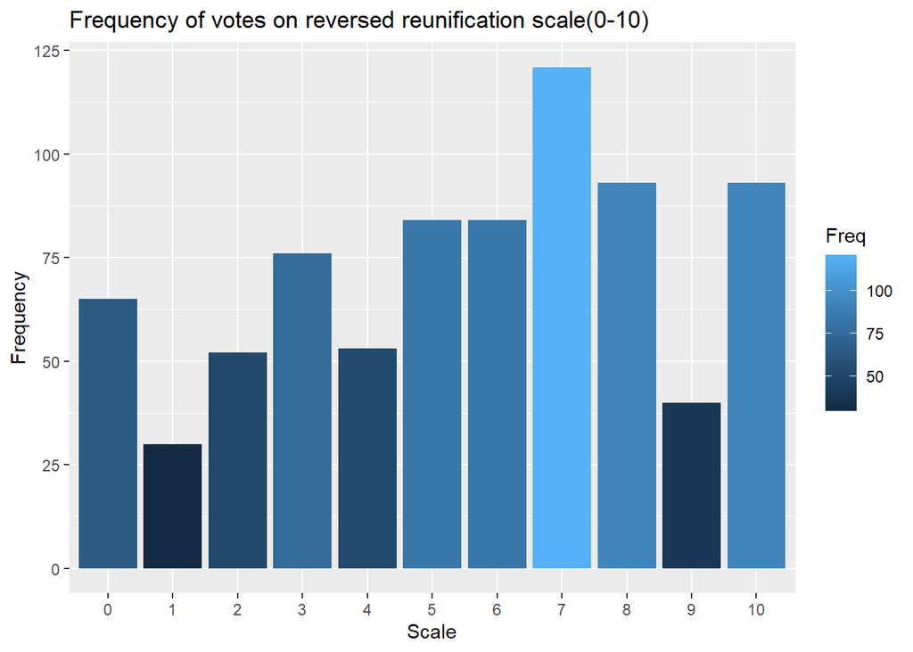

```r
#Barplot
library(tidyverse)
ggplot(data = reunification_reversed_table.df, mapping = aes(x = Var1, y = Freq, fill = Freq)) + labs(x = "Scale", y = "Frequency", title = "Frequency of votes on reversed reunification scale(0-10)") +
  geom_col()
```

*Looking at the bar plot, we can say that it is not exactly normally distributed, it looks slightly skewed to the left as higher frequencies can be seen towards the right of the scale.*

### Part 4

The variable ``firstPref` asks respondents about their first-preference vote choice. Create a cross-table of this variable. For which parties do we have fewer than 30 observations? Create a new variable (`party_recoded`) that recodes these parties into the category `Other Parties`. You can use, for instance, the `recode()` function from the **dplyr** package, which is included in the **tidyverse**. [10 points]

```r
#Cross table for firstPref
first_pref <- table(dat_lines$firstPref)
first_pref
```

```
           Aontu      Fianna Fail        Fine Gael      Green Party
              24              159              167              110
     Independent   Inds. 4 Change Irish Democratic    Irish Freedom
             105                5                1                6
    Labour Party   National Party            Renua        Sinn Fein
              47                6                6              284
Social Democrats   Solidarity PBP   Workers' Party
              40               40                0
```

*The following parties have fewer than 30 observations:*

*Aontu, Inds. 4 Change, Irish Democratic, Irish Freedom, National Party, Renua, Workers’ Party.*

```r
#Recode the parties into the category 'other parties'
dat_lines <- dat_lines |> mutate( party_recoded = recode(firstPref,
        "Aontu" = "Other parties" ,
        "Inds. 4 Change" = "Other parties",
        "Irish Democratic" = "Other parties",
        "Irish Freedom" = "Other parties",
        "National Party" = "Other parties",
        "Renua" = "Other parties",
        "Workers' Party" = "Other parties"))
```

### Part 5

Create a new data frame that groups the data by `party_recoded`. Calculate the mean and standard deviation of `reunification_reversed` across parties. [5 points]

```r
#New dataframe groubed by 'party_recoded'
Partyrecoded_new_data = dat_lines %>% group_by(party_recoded)
```

```r
#Mean and sd of reunification reversed
Partyrecoded_new_data <- Partyrecoded_new_data %>%
  summarise(mean(reunification_reversed, na.rm = TRUE),                 sd(reunification_reversed, na.rm = TRUE)) %>%
               as.data.frame()
colnames(Partyrecoded_new_data) <- c("party_recoded","reunification_reversed_mean","reunification_reversed_sd")

Partyrecoded_new_data
```

```
     party_recoded reunification_reversed_mean reunification_reversed_sd
1    Other parties                    5.142857                  3.257797
2      Fianna Fail                    4.780952                  3.044481
3        Fine Gael                    4.208955                  2.799234
4      Green Party                    5.226190                  2.426516
5      Independent                    5.243902                  2.996133
6     Labour Party                    5.000000                  2.776206
7        Sinn Fein                    6.805785                  2.766030
8 Social Democrats                    5.466667                  2.991175
9   Solidarity PBP                    6.900000                  2.758685
```

### Part 6

Use `arrange()` to identify voters of the party with the highest mean of `reunification_reversed`. Use `arrange()` again to determine the party with the highest standard deviation of `reunification_reversed`. What does a higher standard deviation mean in substantive terms? [5 points]

```r
#Arrange mean of reunification_reversed in descending order
Partyrecoded_new_data %>%
  arrange(desc(reunification_reversed_mean))
```

```
     party_recoded reunification_reversed_mean reunification_reversed_sd
1   Solidarity PBP                    6.900000                  2.758685
2        Sinn Fein                    6.805785                  2.766030
3 Social Democrats                    5.466667                  2.991175
4      Independent                    5.243902                  2.996133
5      Green Party                    5.226190                  2.426516
6    Other parties                    5.142857                  3.257797
7     Labour Party                    5.000000                  2.776206
8      Fianna Fail                    4.780952                  3.044481
9        Fine Gael                    4.208955                  2.799234
```

*The highest mean of ‘reunification_reversed’ is for the party ‘Solidarity PBP’ i.e., 6.9.*

```r
#Arrange sd of reunification_reversed in descending order
Partyrecoded_new_data %>%
  arrange(desc(reunification_reversed_sd))
```

```
     party_recoded reunification_reversed_mean reunification_reversed_sd
1    Other parties                    5.142857                  3.257797
2      Fianna Fail                    4.780952                  3.044481
3      Independent                    5.243902                  2.996133
4 Social Democrats                    5.466667                  2.991175
5        Fine Gael                    4.208955                  2.799234
6     Labour Party                    5.000000                  2.776206
7        Sinn Fein                    6.805785                  2.766030
8   Solidarity PBP                    6.900000                  2.758685
9      Green Party                    5.226190                  2.426516
```

*The highest standard deviation of ‘reunification_reversed’ is for the category ‘other parties’ combined i.e., 3.257797.*

*A high standard deviation indicates that data are more spread out from the mean.*

### Part 7

Create a plot showing the average value and the range of ±1 standard deviation, based on the data frame created in question 5. Use `coord_flip()` to show the parties on the y-axis. Reorder the parties in descending order (meaning that the party whose voters most support reunification appears at the top of the graph). You can use `geom_pointrange()` for this. [Note: you’ll find many tutorials on `geom_pointrange()` online; Healy (2019), which is on the syllabus, also covers these plots]. [5 points]

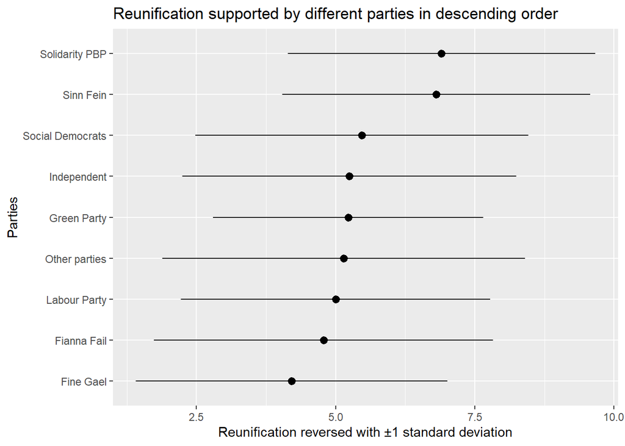

```r
# Plot
ggplot(Partyrecoded_new_data, aes(x = reorder(party_recoded,reunification_reversed_mean), y = reunification_reversed_mean)) +
  geom_pointrange(aes(ymin = reunification_reversed_mean - reunification_reversed_sd, ymax = reunification_reversed_mean + reunification_reversed_sd)) + coord_flip() +
                    labs(x = "Parties", y = "Reunification reversed with ±1 standard deviation", title = "Reunification supported by different parties in descending order")
```

### Part 8

Use the respondent-level data frame (created in Question 4) and run a linear regression model with `reunification_reversed` as the dependent variable and `age` as the independent variable. Use `summary()` to inspect the coefficients, and interpret the coefficients for `age`. [10 points]

```r
# Linear model
reunification_reversed_model <- lm(reunification_reversed ~ age, data = dat_lines)
summary(reunification_reversed_model)
```

```
Call:
lm(formula = reunification_reversed ~ age, data = dat_lines)

Residuals:
    Min      1Q  Median      3Q     Max
-6.2793 -2.2793  0.3217  2.1818  5.1818

Coefficients:
            Estimate Std. Error t value Pr(>|t|)
(Intercept)   6.2315     0.2842  21.926  < 2e-16 ***
age25-34      0.0478     0.3992   0.120 0.904723
age35-44     -0.5532     0.3765  -1.469 0.142201
age45-54     -0.7163     0.3656  -1.960 0.050406 .
age55-64     -1.4133     0.3765  -3.754 0.000187 ***
age65+       -1.2815     0.3917  -3.271 0.001118 **
---
Signif. codes:  0 '***' 0.001 '**' 0.01 '*' 0.05 '.' 0.1 ' ' 1

Residual standard error: 2.953 on 784 degrees of freedom
  (210 observations deleted due to missingness)
Multiple R-squared:  0.03273,   Adjusted R-squared:  0.02656
F-statistic: 5.306 on 5 and 784 DF,  p-value: 8.383e-05
```

*In this linear model, we see that the age variable is a categorical variable with the youngest category to be 18-24 and the oldest category to be 65+. Looking at the regression coefficients, the age category 18-24 is used as a reference level and we compare all the other age coefficients to this reference value. The reunification wanted for the age category 25-34 is 0.0478 percentage points higher than the reunification wanted for the category 18-24, keeping all other variables constant. The reunification wanted for age category 35-44 is 0.5532 percentage points lower than that of category 18-24. Similarly, the reunification wanted for age categories 45-54,55-64 and 65+ is 0.7163, 1.4133 and 1.2815 percentage points lower than the reunification wanted for age category 18-24 respectively, provided all other variables remain constant.*

### Part 9

Add one additional independent variable that may predict support for reunification. Interpret the coefficient for this variable, and interpret the coefficients for `age` again. How does our interpretation of `age` change in comparison to question 8, and do the age coefficients change substantively after you added a variable? [10 points]

```r
# Reunification reversed regression model with age and education as independent variables
reunification_reversed_age_education_model <- lm(reunification_reversed ~ age + education, data = dat_lines)

summary(reunification_reversed_age_education_model)
```

```
Call:
lm(formula = reunification_reversed ~ age + education, data = dat_lines)

Residuals:
    Min      1Q  Median      3Q     Max
-6.9198 -2.3115  0.3194  2.2390  5.5561

Coefficients:
                                                     Estimate Std. Error
(Intercept)                                           3.99749    2.11247
age25-34                                              0.02546    0.40904
age35-44                                             -0.60806    0.38734
age45-54                                             -0.77925    0.37360
age55-64                                             -1.38691    0.38269
age65+                                               -1.30270    0.40405
education2 - Primary School                           1.84469    2.26509
education3 - Less than Junior/Inter Cert              0.74910    2.23380
education4 - Secondary School Junior Cert/Inter Cert  2.92227    2.12208
education5 - Secondary School Leaving Cert            2.06617    2.10722
education6 - Post Leaving Cert Qualifications         2.23808    2.10518
education7 - Third Level Degree                       2.29496    2.09405
                                                     t value Pr(>|t|)
(Intercept)                                            1.892 0.058818 .
age25-34                                               0.062 0.950383
age35-44                                              -1.570 0.116859
age45-54                                              -2.086 0.037321 *
age55-64                                              -3.624 0.000309 ***
age65+                                                -3.224 0.001317 **
education2 - Primary School                            0.814 0.415665
education3 - Less than Junior/Inter Cert               0.335 0.737453
education4 - Secondary School Junior Cert/Inter Cert   1.377 0.168884
education5 - Secondary School Leaving Cert             0.981 0.327134
education6 - Post Leaving Cert Qualifications          1.063 0.288053
education7 - Third Level Degree                        1.096 0.273441
---
Signif. codes:  0 '***' 0.001 '**' 0.01 '*' 0.05 '.' 0.1 ' ' 1

Residual standard error: 2.948 on 778 degrees of freedom
  (210 observations deleted due to missingness)
Multiple R-squared:  0.04362,   Adjusted R-squared:  0.0301
F-statistic: 3.226 on 11 and 778 DF,  p-value: 0.0002576
```

*I used education level as a second independent variable for my regression model.*

*Education level is a categorical variable ranging from 1-7, where the lowest education level (1) refers to ‘None’ and the highest level (7) refers to ‘Third level degree’. We use education level 1 as a reference level and compare the reunification wanted for all other education levels to this reference level.*

*Interpretation of coefficients:*

*We interpret the age variable again.*

*The reunification wanted for people aged 25-34 is 0.025 percentage points higher than people aged 18-24, reunification wanted for people aged 35-44 is 0.61 percentage points lower than people aged 18-24. Reunification wanted for people aged 45-54 is 0.78 percentage points lower than people aged 18-24. Similarly,reunification wanted for people aged 55-64 and people aged 65+ is 1.39 and 1.30 percentage points lower than people aged 18-24, respectively.*

*Looking at the age coefficients after addition of education variable, we do not see a significant change in the age coefficients in this model. The pattern seems to stay the same with a few decimal points change in the coefficient values.*

## Do Women Promote Different Policies than Men? (40 Points)

(Based on Raghabendra Chattopadhyay and Esther Duflo 2004. “Women as Policy Makers: Evidence from a Randomized Policy Experiment in India.” *Econometrica*, 72 (5): 1409–43.)

In this exercise, we will estimate the effect of having a female politician on two different policy outcomes. For this purpose, we will analyze data from an experiment conducted in India, where villages were randomly assigned to have a female council head. The dataset we will use is in a file called `india.csv`. The list below shows the names and descriptions of the variables in this dataset, where the unit of observation is villages.

- `village`: village identifier
- `female`: whether village was assigned a female politician: 1=yes, 0= no
- `water`: number of new (or repaired) drinking water facilities in the village since random assignment
- `irrigation`: number of new irrigation facilities in the village since random assignment

### Part 1

Load the dataset using `dat_india <- read.csv("india.csv")`. Use the `head()` function to print the first six observations. Substantively interpret the first observation in the dataset. [5 points]

```r
#Load the dataset
#Interpret the first observation
library(readr)
dat_india <- read_csv("india.csv")
head(dat_india)
```

```
# A tibble: 6 × 4
  village      female water irrigation
  <chr>         <dbl> <dbl>      <dbl>
1 GP1_village2      1    10          0
2 GP1_village1      1     0          5
3 GP2_village2      1     2          2
4 GP2_village1      1    31          4
5 GP3_village2      0     0          0
6 GP3_village1      0     0          0
```

*The first observation indicates that GP1_village2 was assigned a female politician, there were 10 new (or repaired) drinking water facilities in the village since random assignment, however, there were no new irrigation facilities in the village since random assignment.*

### Part 2

Run a linear regression that predicts `water` conditional on whether or not a village was assigned a female politician. [5 points]

```r
#Linear regression
lm_water <- lm(water ~ female, data = dat_india)
summary(lm_water)
```

```
Call:
lm(formula = water ~ female, data = dat_india)

Residuals:
    Min      1Q  Median      3Q     Max
-23.991 -14.738  -7.865   2.262 316.009

Coefficients:
            Estimate Std. Error t value Pr(>|t|)
(Intercept)   14.738      2.286   6.446 4.22e-10 ***
female         9.252      3.948   2.344   0.0197 *
---
Signif. codes:  0 '***' 0.001 '**' 0.01 '*' 0.05 '.' 0.1 ' ' 1

Residual standard error: 33.45 on 320 degrees of freedom
Multiple R-squared:  0.01688,   Adjusted R-squared:  0.0138
F-statistic: 5.493 on 1 and 320 DF,  p-value: 0.0197
```

### Part 3

Interpret the coefficient for `female` in substantive terms. (Note: in your final research paper, you will also need to specify the null hypothesis and alternative hypothesis, and interpret the statistical significance. We have not covered this in the lectures yet. Therefore, it is not part of this homework.) [10 points]

*The coefficient for ‘female’ is 9.252. It is a positive number which indicates that villages assigned with female politicians have a higher number of new (or repaired) drinking water facilities in the village since random assignment (around 9.3 more as the coefficient is 9.252). Looking at the intercept, we can state that if a village that did not get a female politician installs 15 (intercept = 14.738, so rounding up) new/repaired water facilities, a village assigned with a female politician will install roughly 9.3 more new/repaired water facilities (i.e., 14.738 + 9.252) i.e., 24 new water facilities.*

*We can also interpret it as, a 1 unit increase in a female politician assigned to a village results in a 9.3 unit increase in new/repaired water facilities.*

### Part 4

Install the **texreg** package in your console, load the package in your script, and use `htmlreg()` and create a publishable regression table. Note: the code chunk needs to include `results='asis'` to ensure that the table is printed correctly in the output file. Don’t change the setting of this code chunk. Make sure to add a caption and relabel the coefficient names. [5 points]

```r
library(texreg)
htmlreg(lm_water,
        custom.coef.names = c(
          "Intercept",
          "Female Politician"

        ),
        caption = "Predicting water facilities depending on appointment of a famale politician",
        caption.above = TRUE)
```

Predicting water facilities depending on appointment of a famale politician

|  | Model 1 |
| --- | --- |
| Intercept | 14.74*** |
|  | (2.29) |
| Female Politician | 9.25* |
|  | (3.95) |
| R<sup>2</sup> | 0.02 |
| Adj. R<sup>2</sup> | 0.01 |
| Num. obs. | 322 |

***p < 0.001; **p < 0.01; *p < 0.05

### Part 5

Write code that would save the regression table (with captions and custom coefficient names) as a word document on your machine. Save the table as `reg_water.doc`. Such a workflow will ensure reproducibility for your research paper and avoids error-prone copy-and-pasting. [5 points]

```r
wordreg(lm_water,
  file="reg_water.doc",
  single.row = FALSE,
  stars = c(0.001, 0.01, 0.05),
  custom.model.names = NULL,
  custom.coef.names = c("Water","Female"),
  digits = 3,
  star.symbol = "*")
```

```
processing file: file1cf866186e29.Rmd
```

[output not shown]

```
output file: file1cf866186e29.knit.md
```

[output not shown]

```
Output created: reg_water.doc
```

Run another regression model with `irrigation` as the dependent variable, and `female` as the independent variable. Interpret the coefficient, standard error, and significance level for `female`. [5 points]

```r
#Regression model with 'irrigation'
lm_irrigation <- lm(irrigation ~ female, data = dat_india)
summary(lm_irrigation)
```

```
Call:
lm(formula = irrigation ~ female, data = dat_india)

Residuals:
   Min     1Q Median     3Q    Max
-3.388 -3.388 -3.019 -1.019 86.612

Coefficients:
            Estimate Std. Error t value Pr(>|t|)
(Intercept)   3.3879     0.6498   5.214 3.33e-07 ***
female       -0.3693     1.1220  -0.329    0.742
---
Signif. codes:  0 '***' 0.001 '**' 0.01 '*' 0.05 '.' 0.1 ' ' 1

Residual standard error: 9.506 on 320 degrees of freedom
Multiple R-squared:  0.0003385, Adjusted R-squared:  -0.002785
F-statistic: 0.1084 on 1 and 320 DF,  p-value: 0.7422
```

*Coefficient- We can see that the coefficient of our regression model is negative, this indicates that villages assigned with a female politician have fewer irrigation facilities has compared to villages without a female politician. i.e., according to the intercept (3.3879), a village not assigned a female politician installs 3 irrigation facilities, in comparison a village assigned with a female politician installs 0.36 less irrigation facilities (coef: -0.3693).*

*Std. error for this regression model for the variable ‘female’ is 1.122, this indicates that the difference between the actual number of irrigation facilities and the number of facilities shown in the model is 1.122.*

*The coefficient ‘female’ is not significant at 0.001, 0.01, 0.05 or 0.1 significance level.*

### Part 7

Use `htmlreg()` again and create a regression table that contains both models (the one created in questions 3 and 5). Adjust the model names to “Model 1: Water” and “Model 2: Irrigation” and adjust the coefficient names. [5 points]

```r
library(texreg)
htmlreg(list(lm_water, lm_irrigation),
        custom.coef.names = c(
          "Intercept",
          "Female Politician"

        ),
        custom.model.names = c("Model 1: Water", "Model 2: Irrigation"),

        caption = "Predicting water and irrigation facilities depending on appointment of a famale politician",
        caption.above = TRUE)
```

Predicting water and irrigation facilities depending on appointment of a famale politician

|  | Model 1: Water | Model 2: Irrigation |
| --- | --- | --- |
| Intercept | 14.74*** | 3.39*** |
|  | (2.29) | (0.65) |
| Female Politician | 9.25* | -0.37 |
|  | (3.95) | (1.12) |
| R<sup>2</sup> | 0.02 | 0.00 |
| Adj. R<sup>2</sup> | 0.01 | -0.00 |
| Num. obs. | 322 | 322 |

***p < 0.001; **p < 0.01; *p < 0.05

### Part8

**BONUS**: State the (preliminary) research question of your research paper, the dependent variable and the main independent variable, and a dataset that you could use to test your research question. [3 points]

*Given below are my current possible research question, variables and data source.*

*Possible Question - How does Socio-economic Status (SES) and Lifestyle of a person impact their physical health.*

*Variables - Main dependent variable is physical health and main independent variables can be income, age, physical activity etc.*

*A possible dataset could be obtained from The Irish Longitudinal Study on Ageing (TILDA).*